# RSJI: Racial and Social Justice Initiative

Jake Johnson

10/23/2017

# 1 Data

## 1.1 Seattle Incident-Based Reporting

Below are maps which show the spatial locations of all SPD incidents in 2016 for which data is available. The full data set is available [here](https://data.seattle.gov/Public-Safety/Seattle-Police-Department-Police-Report-Incident/7ais-f98f). Each map corresponds to one of the Uniform Crime Reporting (UCR)’s 12 categories while the colored areas delineate one of SPD’s 17 policing sectors.

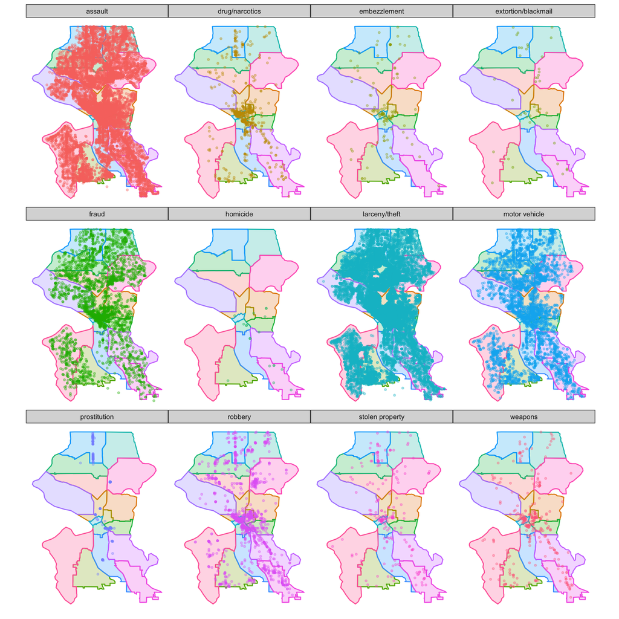

## 1.2 National Incident-Based Reporting

Unfortunately, the data presented above do not include any demographic information; this is obviously problematic when one is interested in examining crime data along racial dimensions. Fortunately, SPD participates in the National Incident-Based Reporting System ([NIBRS](https://www.icpsr.umich.edu/icpsrweb/ICPSR/series/128)) and some of the records submitted into this system do contain demographic information. These are summarized below:

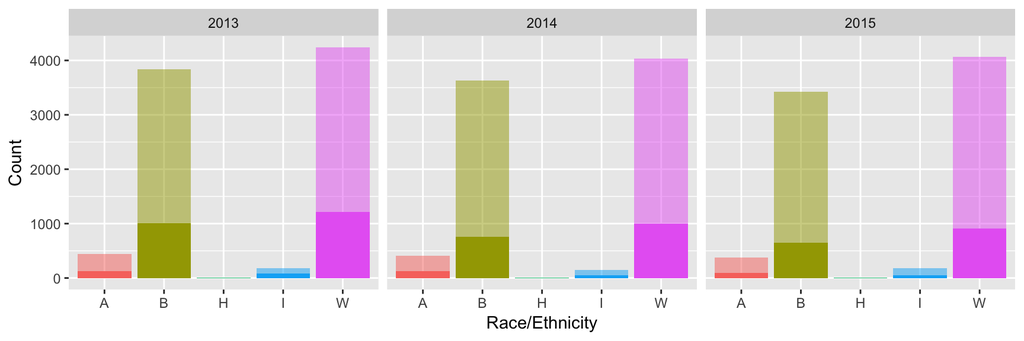

where: A indicates Asian, B indicates Black, H indicates Hispanic, I indicates Alaska Native or American Indian, and W indicates White. The solid portion of each bar in the plot above represents data found in the Arrestee segment of the NIBRS data set while the transparent portion represents data found in the Offender segment of the data set.

## 1.3 Terry stops

SPD’s Terry stop data can be found [here](https://data.seattle.gov/Public-Safety/Terry-Stops/28ny-9ts8). The demographic information is summarized below:

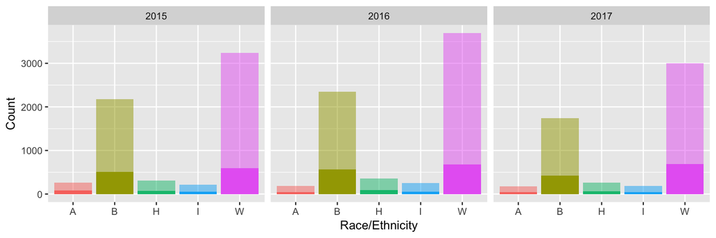

where A, B, H, I, and W are defined as above. In this case, the solid portion of each bar represents stops that led to an arrest while the transparent portion represents stops that did not.

## 1.4 American Community Survey

# 2 Models

For each race $r = \{A, B, I, W\}$ and sector $s$, the annunal number of Terry stops $y_{rs}$ is modeled as an overdispersed Poisson regression using the previous year’s arrests $a_{rs}$ as an offset:

$$\begin{equation}
y_{rs} \sim \text{Poisson} \left( a_{rs} e^{\mu + \alpha_r + \beta_s + \epsilon_{rs}} \right)
\tag{2.1}
\end{equation}$$

The $\alpha_r$’s control for each race, the $\beta_s$’s account for variation between sectors, and the $\epsilon_{rs}$’s allow for overdispersion.

In addition, the proportion of the sector’s population that is black $z_{1s}$ is also added as a predictor in the regression above:

$$\begin{equation}
y_{rs} \sim \text{Poisson} \left( a_{rs} e^{\mu + \alpha_r + \beta_s + \rho z_{1s} + \epsilon_{rs}} \right)
\tag{2.2}
\end{equation}$$

The offset $a_{rs}$ can also be modeled more flexibly by including it as a predictor with its own coefficent:

$$\begin{equation}
y_{rs} \sim \text{Poisson} \left( e^{\gamma \log(a_{rs}) + \mu + \alpha_r + \beta_s + \epsilon_{rs}} \right)
\tag{2.3}
\end{equation}$$

Flexibility is also added by assuming that both the Terry stops $y_{st}$ and the previous year’s arrests $a_{rs}$ are distributed Poisson with mean equal to the true crime rate $\theta_{rs}$. This rate is then modeled as function of each race’s population in the sector $p_{rs}$ and an additional set of race and sector parameters $\delta_r$ and $\zeta_s$:

$$\begin{equation}
\begin{split}
y_{rs} &\sim \text{Poisson} \left( \theta_{rs} e^{\mu + \alpha_r + \beta_s + \epsilon_{rs}} \right) \\
a_{rs} &\sim \text{Poisson} \left( \theta_{rs} \right) \\
\log(\theta_{rs}) &= \log(p_{rs}) + \delta_r + \zeta_s + \nu_{rs}
\end{split}
\tag{2.4}
\end{equation}$$

Additionally, each sector’s log median income $z_{2s}$ and proportion of the population with at least a four-year degree $z_{3s}$ are included as predictors for the true crime rate:

$$\begin{equation}
\log(\theta_{rs}) = \log(p_{rs}) + \delta_r + \zeta_s + \phi z_{2s} + \psi z_{3s} + \nu_{rs}
\tag{2.5}
\end{equation}$$

Lastly, a variant of (2.4) is considered where overdispersion in the model for $a_{rs}$ is allowed for:

$$\begin{equation}
\begin{split}
y_{rs} &\sim \text{Poisson} \left( \theta_{rs} e^{\mu + \alpha_r + \beta_s + \epsilon_{rs}} \right) \\
a_{rs} &\sim \text{Poisson} \left( \theta_{rs} e^{\nu_{rs}} \right) \\
\log(\theta_{rs}) &= \log(p_{rs}) + \delta_r + \zeta_s
\end{split}
\tag{2.6}
\end{equation}$$

with another extension that includes $z_{2s}$ and $z_{3s}$ as predictors in the model for $\theta_{rs}$ similar to (2.5):

$$\begin{equation}
\log(\theta_{rs}) = \log(p_{rs}) + \delta_r + \zeta_s + \phi z_{2s} + \psi z_{3s}
\tag{2.7}
\end{equation}$$

# 3 Results

The models are simulated in $\texttt{Stan}$ using flat priors with the exception of the following:

$$\begin{equation*}
\begin{split}
\alpha_r &\sim N(0, \sigma_{\alpha}) \\
\beta_s &\sim N(0, \sigma_{\beta}) \\
\epsilon_{rs} &\sim N(0, \sigma_{\epsilon}) \\
\sigma_{\alpha} &\sim N(0, 1)
\end{split}
\end{equation*}$$

where $\sigma_{\alpha}$, $\sigma_{\beta}$, and $\sigma_{\epsilon}$ represent the variation in the parameters for race, sector, and overdispersion respectively. A similar set of priors are used for models (2.4), (2.5), (2.6), and (2.7):

$$\begin{equation*}
\begin{split}
\delta_r &\sim N(0, \sigma_{\delta}) \\
\zeta_s &\sim N(0, \sigma_{\zeta}) \\
\nu_{rs} &\sim N(0, \sigma_{\nu}) \\
\sigma_{\delta} &\sim N(0, 1)
\end{split}
\end{equation*}$$

The weakly informative priors for $\sigma_{\alpha}$ and $\sigma_{\delta}$ help rule out extreme values.

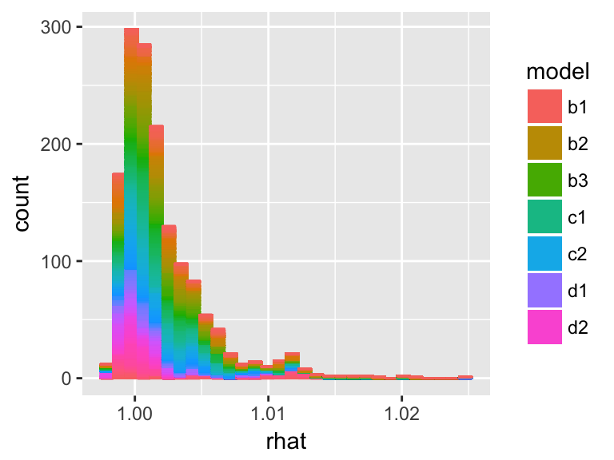

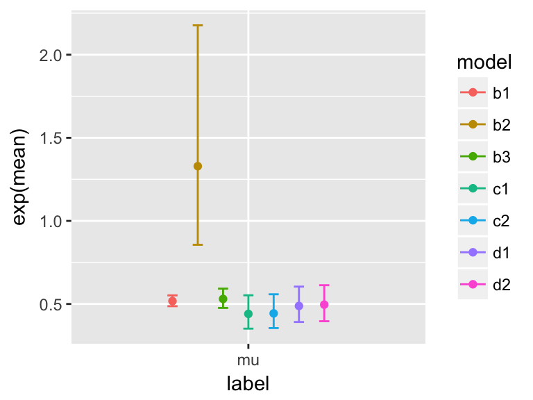

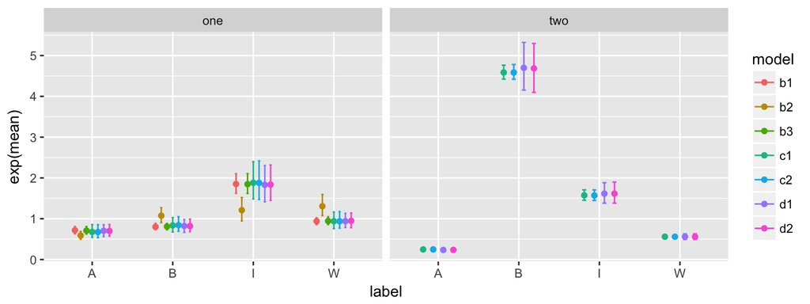

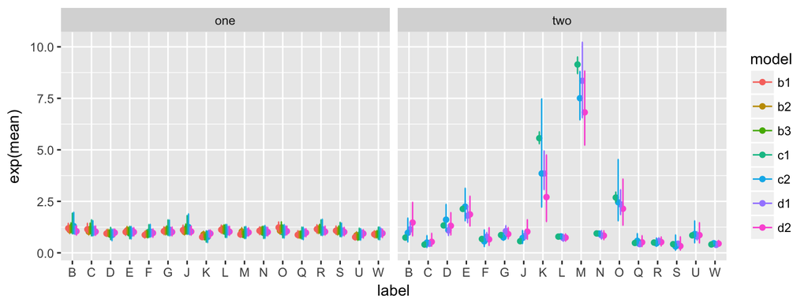

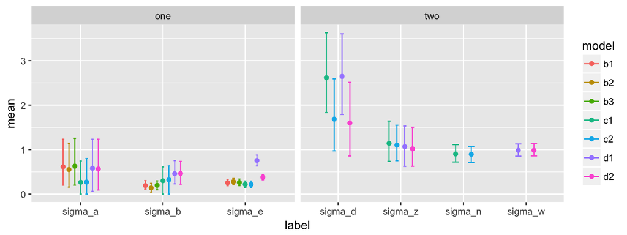